# Final Project

```r
summary(spotify2021)
```

```
##   Track.URI          Track.Name        Artist.URI.s.      Artist.Name.s.
##  Length:104         Length:104         Length:104         Length:104
##  Class :character   Class :character   Class :character   Class :character
##  Mode  :character   Mode  :character   Mode  :character   Mode  :character
##
##
##
##   Album.URI          Album.Name        Album.Artist.URI.s. Album.Artist.Name.s.
##  Length:104         Length:104         Length:104          Length:104
##  Class :character   Class :character   Class :character    Class :character
##  Mode  :character   Mode  :character   Mode  :character    Mode  :character
##
##
##
##  Album.Release.Date Album.Image.URL     Disc.Number      Track.Number
##  Length:104         Length:104         Min.   :0.0000   Min.   : 0.00
##  Class :character   Class :character   1st Qu.:1.0000   1st Qu.: 1.00
##  Mode  :character   Mode  :character   Median :1.0000   Median : 2.50
##                                        Mean   :0.9615   Mean   : 4.75
##                                        3rd Qu.:1.0000   3rd Qu.: 8.00
##                                        Max.   :1.0000   Max.   :19.00
##  Track.Duration..ms. Track.Preview.URL    Explicit           Popularity
##  Min.   :  5800      Length:104         Length:104         Min.   : 0.00
##  1st Qu.:185466      Class :character   Class :character   1st Qu.:64.75
##  Median :214265      Mode  :character   Mode  :character   Median :72.00
##  Mean   :214333                                            Mean   :68.08
##  3rd Qu.:240593                                            3rd Qu.:79.00
##  Max.   :452573                                            Max.   :93.00
##    Added.By           Added.At
##  Length:104         Length:104
##  Class :character   Class :character
##  Mode  :character   Mode  :character
##
##
##
```

##2. Methods (a) Begin with a description of the data set i. How was this data collected originally (if you know) and how did you go about finding and gaining access to the data set? ##The Data was collected from a develops used website called Exportify ##I had to allow access to my personal spotify account to create a csv file ii. What variables does it contain? (variable type) (b) You can / should include you initial visual exploration of the data set i. Draw the distributions of your variables using the correct visualization (his- tograms, box plots) ##Variables it contains is Artist Name, Popularity, Album Name, Track Duration

##3. Results (a) Here is where you will generate most of your R code to visualize specific effects in your data and conduct the proper analyses. (b) Explain, using your own words, the analyses you have conducted in R and the results you have obtained. (c) Create visualizations that support your analyses.

##Lets Determine my top artists for 2020 & 2021

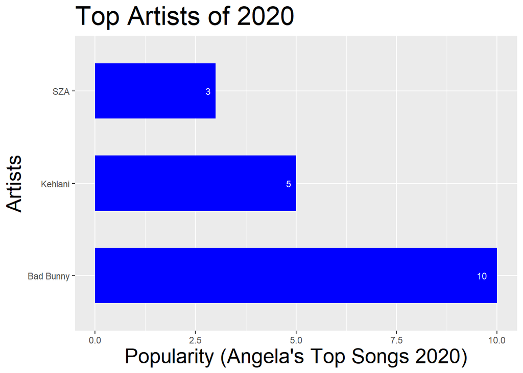

```r
top_artists <- spotify2020 %>%
    group_by(Artist.Name.s.)  %>%
    summarise(Popularity = n()) %>%
    filter(Popularity > 2) %>%
    arrange(desc(Popularity))


ggplot(top_artists, aes(x = Artist.Name.s., y = Popularity)) +
    geom_bar(stat = "identity",  fill = "blue", width = 0.6 ) +
    labs(title = "Top Artists of 2020", x = "Artists", y = "Popularity (Angela's Top Songs 2020)") +
    theme(plot.title = element_text(size=25), axis.title = element_text(size=20)) +
    geom_text(aes(label=Popularity), hjust = 2, size = 3, color = 'white') +
    coord_flip()
```

#Top Artists of 2021

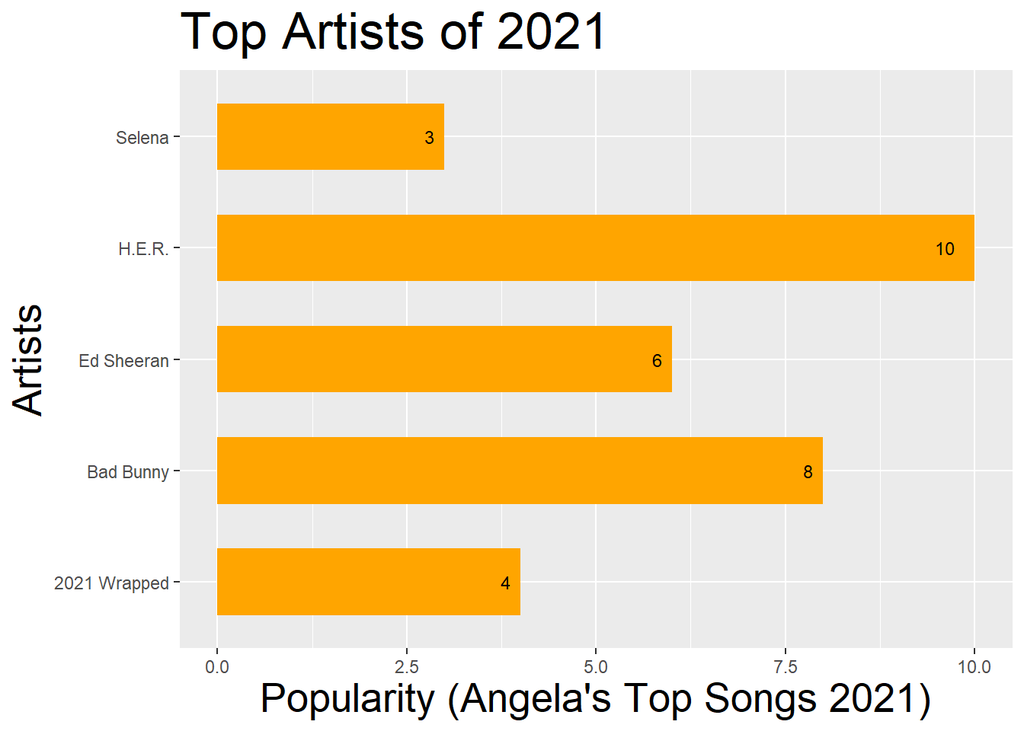

```r
top_artists <- spotify2021 %>%
    group_by(Artist.Name.s.)  %>%
    summarise(Popularity = n()) %>%
    filter(Popularity > 2) %>%
    arrange(desc(Popularity))


ggplot(top_artists, aes(x = Artist.Name.s., y = Popularity)) +
    geom_bar(stat = "identity",  fill = "orange", width = 0.6 ) + #geom_bar() makes the height of the bar proportional to the number of cases in each group
    labs(title = "Top Artists of 2021", x = "Artists", y = "Popularity (Angela's Top Songs 2021)") +
    theme(plot.title = element_text(size=25), axis.title = element_text(size=20)) +
    geom_text(aes(label=Popularity), hjust = 2, size = 3, color = 'black') +
    coord_flip()#coord_flip. Creates Cartesian coordinates with x and y flipped and then convert them with ggplotly
```

#Top Tracks from Most Played Artist of 2020: Bad Bunny

```r
badbunny <- spotify2020 %>%
    filter(Album.Name  == "YHLQMDLG", Artist.Name.s. == "Bad Bunny")

formatted_ed <- badbunny %>%
    group_by(`Track.Name`) %>%
    summarise(Popularity = n()) %>%
    arrange(desc(Popularity))

formatted_ed
```

```
## # A tibble: 9 x 2
##   Track.Name        Popularity
##   <chr>                  <int>
## 1 25/8                       1
## 2 A Tu Merced                1
## 3 La DifÃcil                 1
## 4 La Zona                    1
## 5 Pero Ya No                 1
## 6 Si Veo a Tu MamÃ¡          1
## 7 SoliÃ¡                     1
## 8 Vete                       1
## 9 Yo Perreo Sola             1
```

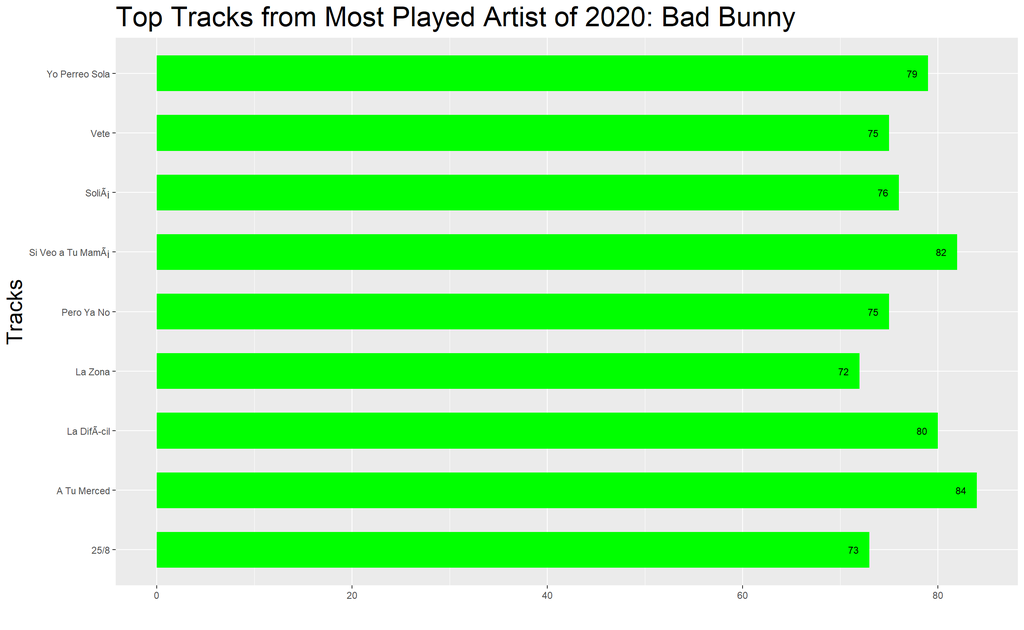

```r
ggplot(badbunny, aes(x = Track.Name, y = Popularity)) +
    geom_bar(stat = "identity",  fill = "green", width = 0.6 ) + #geom_bar() makes the height of the bar proportional to the number of cases in each group
    labs(title = "Top Tracks from Most Played Artist of 2020: Bad Bunny", x = "Tracks", y = "") +
    theme(plot.title = element_text(size=25), axis.title = element_text(size=20)) +
    geom_text(aes(label=Popularity), hjust = 2, size = 3, color = 'black') +
    coord_flip()#coord_flip. Creates Cartesian coordinates with x and y flipped and then convert them with ggplotly
```

```r
her <- spotify2021 %>%
    filter(Album.Name  == "H.E.R.", Artist.Name.s. == "H.E.R.")

formatted_ed <- her %>%
    group_by(`Track.Name`) %>%
    summarise(Popularity = n()) %>%
    arrange(desc(Popularity))

formatted_ed
```

```
## # A tibble: 6 x 2
##   Track.Name        Popularity
##   <chr>                  <int>
## 1 Every Kind Of Way          1
## 2 Focus                      1
## 3 Jungle                     1
## 4 Losing                     1
## 5 Pigment                    1
## 6 U                          1
```

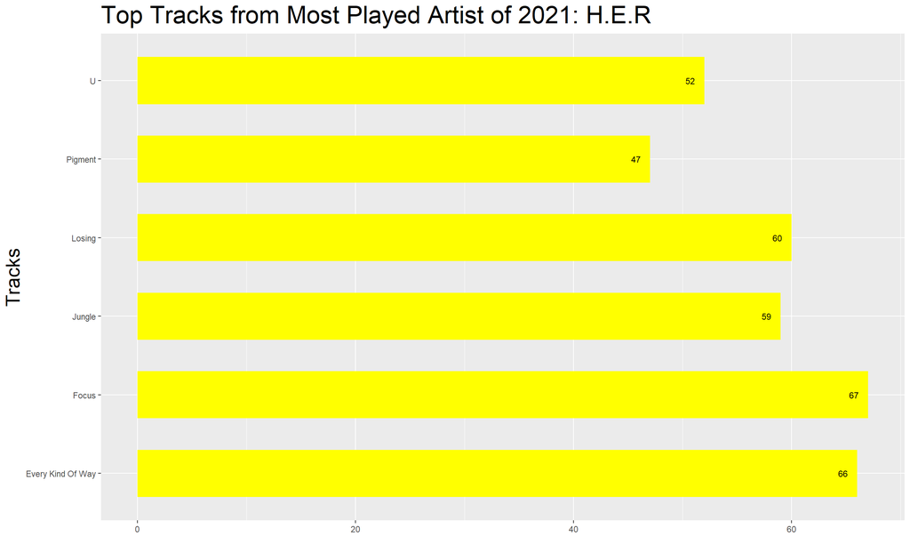

```r
ggplot(her, aes(x = Track.Name, y = Popularity)) +
    geom_bar(stat = "identity",  fill = "yellow", width = 0.6 ) + #geom_bar() makes the height of the bar proportional to the number of cases in each group
    labs(title = "Top Tracks from Most Played Artist of 2021: H.E.R", x = "Tracks", y = "") +
    theme(plot.title = element_text(size=25), axis.title = element_text(size=20)) +
    geom_text(aes(label=Popularity), hjust = 2, size = 3, color = 'black') +
    coord_flip()#coord_flip. Creates Cartesian coordinates with x and y flipped and then convert them with ggplotly
```

##Track Duration for Top 2020 Artist Album ## Bad Bunny ##YHLQMDLG

```r
badbunny <- spotify2020 %>%
    filter(Album.Name  == "YHLQMDLG", Artist.Name.s. == "Bad Bunny")

formatted_bb <- badbunny %>%
    group_by(`Track.Name`) %>%
    arrange((Track.Duration..ms.))

formatted_bb
```

```
## # A tibble: 9 x 18
## # Groups:   Track.Name [9]
##   Track.URI    Track.Name  Artist.URI.s.   Artist.Name.s. Album.URI   Album.Name
##   <chr>        <chr>       <chr>           <chr>          <chr>       <chr>
## 1 spotify:tra~ La Zona     spotify:artist~ Bad Bunny      spotify:al~ YHLQMDLG
## 2 spotify:tra~ SoliÃ¡      spotify:artist~ Bad Bunny      spotify:al~ YHLQMDLG
## 3 spotify:tra~ Pero Ya No  spotify:artist~ Bad Bunny      spotify:al~ YHLQMDLG
## 4 spotify:tra~ La DifÃcil  spotify:artist~ Bad Bunny      spotify:al~ YHLQMDLG
## 5 spotify:tra~ Si Veo a T~ spotify:artist~ Bad Bunny      spotify:al~ YHLQMDLG
## 6 spotify:tra~ Yo Perreo ~ spotify:artist~ Bad Bunny      spotify:al~ YHLQMDLG
## 7 spotify:tra~ A Tu Merced spotify:artist~ Bad Bunny      spotify:al~ YHLQMDLG
## 8 spotify:tra~ Vete        spotify:artist~ Bad Bunny      spotify:al~ YHLQMDLG
## 9 spotify:tra~ 25/8        spotify:artist~ Bad Bunny      spotify:al~ YHLQMDLG
## # ... with 12 more variables: Album.Artist.URI.s. <chr>,
## #   Album.Artist.Name.s. <chr>, Album.Release.Date <chr>,
## #   Album.Image.URL <chr>, Disc.Number <int>, Track.Number <int>,
## #   Track.Duration..ms. <int>, Track.Preview.URL <chr>, Explicit <chr>,
## #   Popularity <int>, Added.By <chr>, Added.At <chr>
```

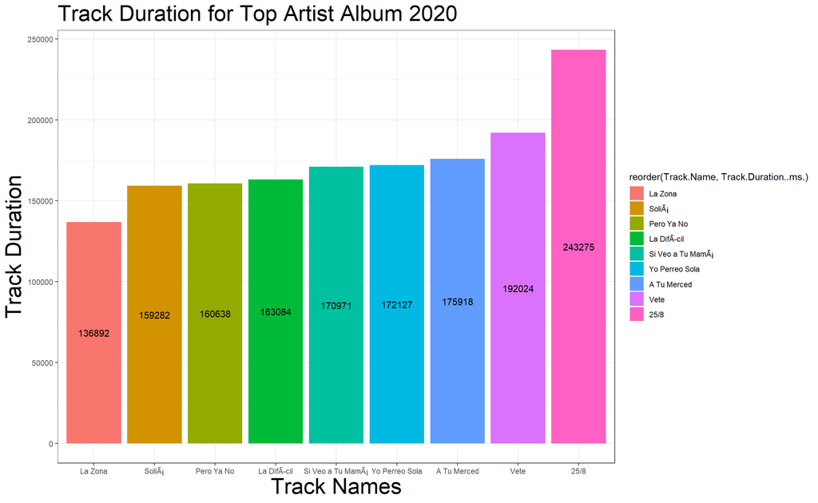

```r
ggplot(formatted_bb, aes(x = reorder(Track.Name,Track.Duration..ms.), y = Track.Duration..ms., fill = reorder(Track.Name,Track.Duration..ms.))) +
    geom_bar(stat = "identity") + labs(title = "Track Duration for Top Artist Album 2020", x = "Track Names", y = "Track Duration") + geom_text(aes(label=Track.Duration..ms.), position = position_stack(vjust = 0.5)) + theme_bw() + theme(plot.title = element_text(size=25), axis.title = element_text(size=25))
```

```r
her <- spotify2021 %>%
    filter(Album.Name  == "H.E.R.", Artist.Name.s. == "H.E.R.")

formatted_her <- her %>%
    group_by(`Track.Name`) %>%
    arrange((Track.Duration..ms.))

formatted_her
```

```
## # A tibble: 6 x 18
## # Groups:   Track.Name [6]
##   Track.URI    Track.Name  Artist.URI.s.   Artist.Name.s. Album.URI   Album.Name
##   <chr>        <chr>       <chr>           <chr>          <chr>       <chr>
## 1 spotify:tra~ Every Kind~ spotify:artist~ H.E.R.         spotify:al~ H.E.R.
## 2 spotify:tra~ U           spotify:artist~ H.E.R.         spotify:al~ H.E.R.
## 3 spotify:tra~ Pigment     spotify:artist~ H.E.R.         spotify:al~ H.E.R.
## 4 spotify:tra~ Focus       spotify:artist~ H.E.R.         spotify:al~ H.E.R.
## 5 spotify:tra~ Losing      spotify:artist~ H.E.R.         spotify:al~ H.E.R.
## 6 spotify:tra~ Jungle      spotify:artist~ H.E.R.         spotify:al~ H.E.R.
## # ... with 12 more variables: Album.Artist.URI.s. <chr>,
## #   Album.Artist.Name.s. <chr>, Album.Release.Date <chr>,
## #   Album.Image.URL <chr>, Disc.Number <int>, Track.Number <int>,
## #   Track.Duration..ms. <int>, Track.Preview.URL <chr>, Explicit <chr>,
## #   Popularity <int>, Added.By <chr>, Added.At <chr>
```

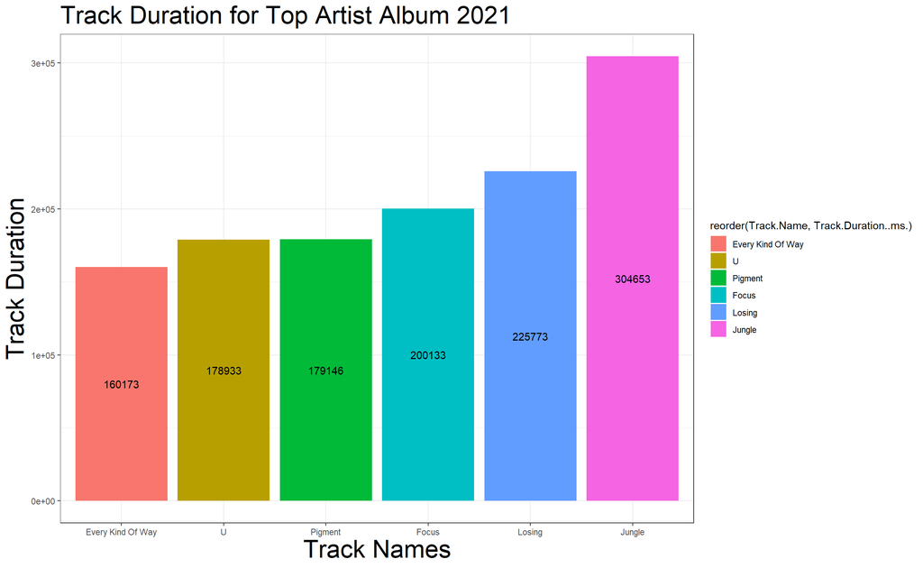

```r
ggplot(formatted_her, aes(x = reorder(Track.Name,Track.Duration..ms.), y = Track.Duration..ms., fill = reorder(Track.Name,Track.Duration..ms.))) +
    geom_bar(stat = "identity") + labs(title = "Track Duration for Top Artist Album 2021", x = "Track Names", y = "Track Duration") + geom_text(aes(label=Track.Duration..ms.), position = position_stack(vjust = 0.5)) + theme_bw() + theme(plot.title = element_text(size=25), axis.title = element_text(size=25))
```

## Density PLot for 2020 Popularity, this will show how many songs within my top playlist are the most popular with other users

```r
pop_density <- ggplot(spotify2020) +
    geom_density(aes(Popularity, fill ="Popularity")) +
    scale_x_continuous(name = "Popularity") +
    scale_y_continuous(name = "Density") +
    ggtitle("Density Plot: Top Songs 2020 Popularity") +
    theme_bw()
    theme(plot.title = element_text(size = 14),
            text = element_text(size = 12)) +
    theme(legend.title=element_blank())
```

[output not shown]

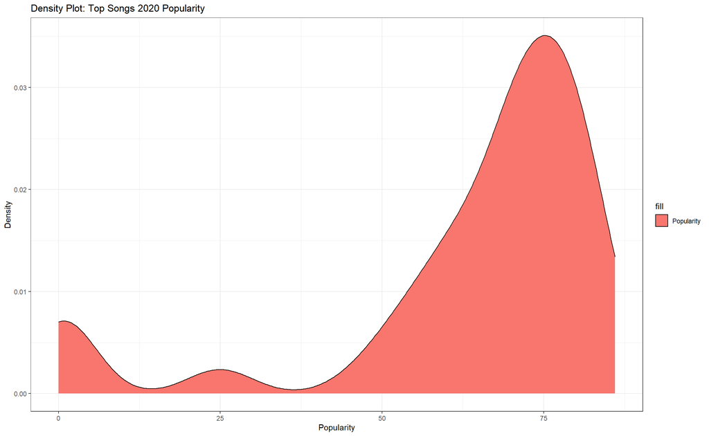

```r
print(pop_density)
```

## Density PLot for 2021 Popularity, this will show how many songs within my top playlist are the most popular with other users

```r
pop_density <- ggplot(spotify2021) +
    geom_density(aes(Popularity, fill ="Popularity")) +
    scale_x_continuous(name = "Popularity") +
    scale_y_continuous(name = "Density") +
    ggtitle("Density Plot: Top Songs 2020 Popularity") +
    theme_bw()
    theme(plot.title = element_text(size = 14),
            text = element_text(size = 12)) +
    theme(legend.title=element_blank())
```

[output not shown]

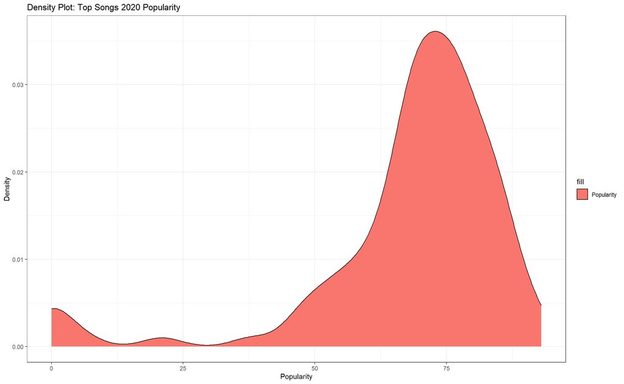

```r
print(pop_density)
```

## Track Duration for 2020 , this will show how many songs fall within the same time slots ( this could be for purposes of having a song short / long enough for a user )

```r
pop_density <- ggplot(spotify2020) +
    geom_density(aes(Track.Duration..ms., fill ="Track Duration")) +
    scale_x_continuous(name = "Track Duration ") +
    scale_y_continuous(name = "Density") +
    ggtitle("Density Plot: Top Songs 2020 Track Duration") +
    theme_bw()
    theme(plot.title = element_text(size = 14),
            text = element_text(size = 12)) +
    theme(legend.title=element_blank())
```

[output not shown]

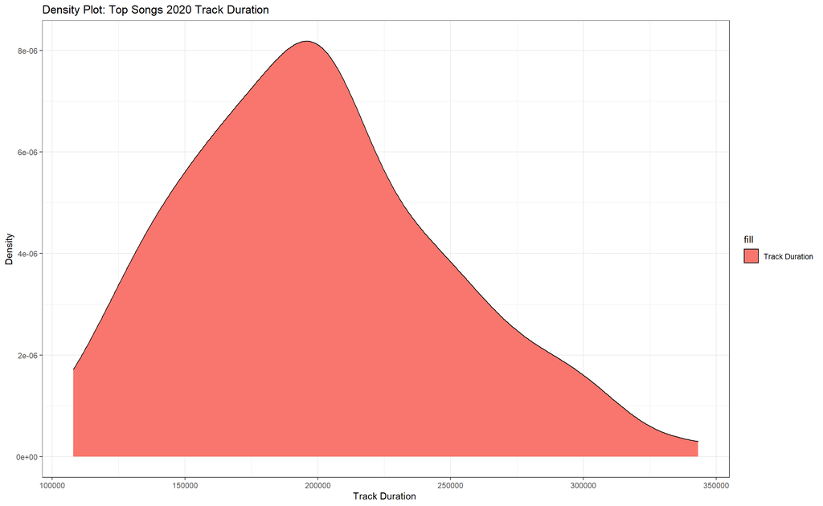

```r
pop_density
```

```r
pop_density <- ggplot(spotify2021) +
    geom_density(aes(Track.Duration..ms., fill ="Track Duration")) +
    scale_x_continuous(name = "Track Duration ") +
    scale_y_continuous(name = "Density") +
    ggtitle("Density Plot: Top Songs 2021 Track Duration") +
    theme_bw()
    theme(plot.title = element_text(size = 14),
            text = element_text(size = 12)) +
    theme(legend.title=element_blank())
```

[output not shown]

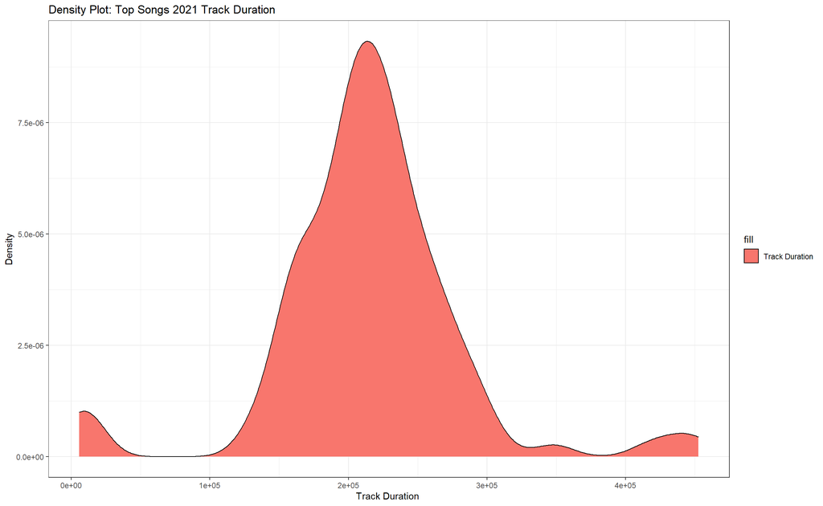

```r
pop_density
```

##4. Discussion (a) What are the conclusions that you draw from your analyses? ##Conclusions I made from this analysis is that over one year time a music artits can change ##By linking popularity to the artist proves how influence can affect ones music taste as they can ##Hear them more frequently thus adding it to their playlist. (b) How do these conclusions answer your research questions? #These conclusions help answer my research questions in a visual manner showing how frequently ##One artist shows up and how that can add to them becoming my top artist for 2020 & 2021 (c) How do these conclusion affect the topic on a larger scale? i. What should the reader take home from your analysis of the data set you selected? ##The reader should take home from my analysis is that you can learn a lot about yourself ##within doing research regarding your own taste. By doing this it helps me understand #How & why a song is popular and how it ending up on my playlist.